# Binary Classification Model for Bank Marketing Using R, Take 2

David Lowe

May 4, 2018

Template Credit: Adapted from a template made available by Dr. Jason Brownlee of Machine Learning Mastery (http://machinelearningmastery.com/)

Dataset Used: Bank Marketing Data Set

Data Set ML Model: Binary classification with numerical and categorical attributes

Dataset Reference: http://archive.ics.uci.edu/ml/datasets/bank+marketing

One source of potential performance benchmarks: https://www.kaggle.com/rouseguy/bankbalanced

INTRODUCTION: The Bank Marketing dataset involves predicting the whether the bank clients will subscribe (yes/no) a term deposit (target variable). It is a binary (2-class) classification problem. There are over 45,000 observations with 16 input variables and 1 output variable. There are no missing values within the dataset.

CONCLUSION: The take No.2 version of this banking dataset aims to test the removal of one attribute from the dataset and the effect. You can see the results from the take No.1 here on the website: https://daines-analytics.com/wp-content/uploads/2018/04/r-classification-Bank_Marketing_Take1.html.

The data removed was the “duration” attribute. According to the dataset documentation, this attribute highly affects the output target (e.g., if duration=0 then y=“no”). However, the duration is not known before a call is performed. Also, after the end of the call, the target variable is naturally identified. Thus, this input should only be included for benchmark purposes and should be discarded if the intention is to have a realistic predictive model.

The purpose of this project is to analyze predictions using various machine learning algorithms and to document the steps using a template. Working through machine learning problems from end-to-end requires a structured modeling approach. Working problems through a project template can also encourage us to think about the problem more critically, to challenge our assumptions, and to get proficient at all parts of a modeling project.

The project aims to touch on the following areas:

1. Document a predictive modeling problem end-to-end.
2. Explore data cleaning and transformation options
3. Explore non-ensemble and ensemble algorithms for baseline model performance
4. Explore algorithm tuning techniques for improving model performance

Any predictive modeling machine learning project genrally can be broken down into about six major tasks:

1. Prepare Problem
2. Summarize Data
3. Prepare Data
4. Model and Evaluate Algorithms
5. Improve Accuracy or Results
6. Finalize Model and Present Results

## 1. Prepare Problem

### 1.a) Load libraries

```r
library(caret)
library(ROCR)
```

### 1.b) Load training

```r
startTimeScript <- proc.time()
entireDataset <- read.csv2("bank-full.csv", header= TRUE)

#Dropping the duration column to prevent future from leaking into the present
entireDataset$duration <- NULL

# Use variable totCol to hold the number of columns in the dataframe
totCol <- ncol(entireDataset)

# Rename the class column to a standard label
colnames(entireDataset)[ncol(entireDataset)] <- "targetVar"
```

## 2. Summarize Data

To gain a better understanding of the data that we have on-hand, we will leverage a number of descriptive statistics and data visualization techniques. The plan is to use the results to consider new questions, review assumptions, and validate hypotheses that we can investigate later with specialized models.

### 2.a) Descriptive statistics

#### 2.a.i) Peek at the data itself.

```r
head(entireDataset)
```

```
##   age          job marital education default balance housing loan contact
## 1  58   management married  tertiary      no    2143     yes   no unknown
## 2  44   technician  single secondary      no      29     yes   no unknown
## 3  33 entrepreneur married secondary      no       2     yes  yes unknown
## 4  47  blue-collar married   unknown      no    1506     yes   no unknown
## 5  33      unknown  single   unknown      no       1      no   no unknown
## 6  35   management married  tertiary      no     231     yes   no unknown
##   day month campaign pdays previous poutcome targetVar
## 1   5   may        1    -1        0  unknown        no
## 2   5   may        1    -1        0  unknown        no
## 3   5   may        1    -1        0  unknown        no
## 4   5   may        1    -1        0  unknown        no
## 5   5   may        1    -1        0  unknown        no
## 6   5   may        1    -1        0  unknown        no
```

#### 2.a.ii) Dimensions of the dataset.

```r
dim(entireDataset)
```

```
## [1] 45211    16
```

#### 2.a.iii) Types of the attributes.

```r
sapply(entireDataset, class)
```

```
##       age       job   marital education   default   balance   housing
## "integer"  "factor"  "factor"  "factor"  "factor" "integer"  "factor"
##      loan   contact       day     month  campaign     pdays  previous
##  "factor"  "factor" "integer"  "factor" "integer" "integer" "integer"
##  poutcome targetVar
##  "factor"  "factor"
```

#### 2.a.iv) Statistical summary of all attributes.

```r
summary(entireDataset)
```

```
##       age                 job           marital          education
##  Min.   :18.00   blue-collar:9732   divorced: 5207   primary  : 6851
##  1st Qu.:33.00   management :9458   married :27214   secondary:23202
##  Median :39.00   technician :7597   single  :12790   tertiary :13301
##  Mean   :40.94   admin.     :5171                    unknown  : 1857
##  3rd Qu.:48.00   services   :4154
##  Max.   :95.00   retired    :2264
##                  (Other)    :6835
##  default        balance       housing      loan            contact
##  no :44396   Min.   : -8019   no :20081   no :37967   cellular :29285
##  yes:  815   1st Qu.:    72   yes:25130   yes: 7244   telephone: 2906
##              Median :   448                           unknown  :13020
##              Mean   :  1362
##              3rd Qu.:  1428
##              Max.   :102127
##
##       day            month          campaign          pdays
##  Min.   : 1.00   may    :13766   Min.   : 1.000   Min.   : -1.0
##  1st Qu.: 8.00   jul    : 6895   1st Qu.: 1.000   1st Qu.: -1.0
##  Median :16.00   aug    : 6247   Median : 2.000   Median : -1.0
##  Mean   :15.81   jun    : 5341   Mean   : 2.764   Mean   : 40.2
##  3rd Qu.:21.00   nov    : 3970   3rd Qu.: 3.000   3rd Qu.: -1.0
##  Max.   :31.00   apr    : 2932   Max.   :63.000   Max.   :871.0
##                  (Other): 6060
##     previous           poutcome     targetVar
##  Min.   :  0.0000   failure: 4901   no :39922
##  1st Qu.:  0.0000   other  : 1840   yes: 5289
##  Median :  0.0000   success: 1511
##  Mean   :  0.5803   unknown:36959
##  3rd Qu.:  0.0000
##  Max.   :275.0000
##
```

#### 2.a.v) Summarize the levels of the class attribute.

```r
entireDataset_x <- entireDataset[,1:(totCol-1)]
entireDataset_y <- entireDataset[,totCol]
cbind(freq=table(entireDataset_y), percentage=prop.table(table(entireDataset_y))*100)
```

```
##      freq percentage
## no  39922   88.30152
## yes  5289   11.69848
```

#### 2.a.vi) Count missing values.

```r
sapply(entireDataset, function(x) sum(is.na(x)))
```

```
##       age       job   marital education   default   balance   housing
##         0         0         0         0         0         0         0
##      loan   contact       day     month  campaign     pdays  previous
##         0         0         0         0         0         0         0
##  poutcome targetVar
##         0         0
```

### 2.b) Data visualizations

#### 2.b.i) Univariate plots to better understand each attribute.

```r
# Set up a variable for the total number of attribute columns (totAttr)
totAttr <- totCol-1
# Set up the number of row and columns for visualization display. dispRow * dispCol should be >= totAttr
dispCol <- 4
if (totAttr%%dispCol == 0) {
dispRow <- totAttr%/%dispCol
} else {
dispRow <- (totAttr%/%dispCol) + 1
}
```

```r
# Boxplots for each attribute
#par(mfrow=c(dispRow,dispCol))
#for(i in 1:totAttr) {
#   boxplot(entireDataset[,i], main=names(entireDataset)[i])
#}
```

```r
# Histograms each attribute
#par(mfrow=c(dispRow,dispCol))
#for(i in 1:totAttr) {
#   hist(entireDataset[,i], main=names(entireDataset)[i])
#}
```

```r
# Density plot for each attribute
#par(mfrow=c(dispRow,dispCol))
#for(i in 1:totAttr) {
#   plot(density(entireDataset[,i]), main=names(entireDataset)[i])
#}
```

#### 2.b.ii) Multivariate plots to better understand the relationships between attributes

```r
# Scatterplot matrix colored by class
#pairs(targetVar~., data=entireDataset, col=training$targetVar)
```

```r
# Box and whisker plots for each attribute by class
#scales <- list(x=list(relation="free"), y=list(relation="free"))
#featurePlot(x=entireDataset_x, y=entireDataset_y, plot="box", scales=scales)
```

```r
# Density plots for each attribute by class value
#featurePlot(x=entireDataset_x, y=entireDataset_y, plot="density", scales=scales)
```

```r
# Correlation plot
#correlations <- cor(entireDataset_x)
#corrplot(correlations, method="circle")
```

## 3. Prepare Data

Some training may require additional preparation activities that will best exposes the structure of the problem and the relationships between the input attributes and the output variable. Some data-prep tasks might include:

- Cleaning data by removing duplicates, marking missing values and even imputing missing values.
- Feature selection where redundant features may be removed.
- Data transforms where attributes are scaled or redistributed in order to best expose the structure of the problem later to learning algorithms.

### 3.a) Data Cleaning

```r
# Not applicable for this iteration of the project.

# Mark missing values
#invalid <- 0
#entireDataset$some_col[entireDataset$some_col==invalid] <- NA

# Impute missing values
#entireDataset$some_col <- with(entireDataset, impute(some_col, mean))
```

### 3.b) Feature Selection

```r
# Not applicable for this iteration of the project.
```

### 3.c) Data Transforms

```r
# Not applicable for this iteration of the project.
```

### 3.d) Split-out training and validation trainings

We create a training training (variable name “training”) and a validation training (variable name “validation”).

```r
seedNum <- 888
set.seed(seedNum)

# Create a list of 80% of the rows in the original training we can use for training
training_index <- createDataPartition(entireDataset$targetVar, p=0.80, list=FALSE)

# Use 80% of data to training and testing the models
training <- entireDataset[training_index,]

# Select the remaining 20% of the data for validation
validation <- entireDataset[-training_index,]
```

## 4. Model and Evaluate Algorithms

After the data-prep, we next work on finding a workable model by evaluating a subset of machine learning algorithms that are good at exploiting the structure of the training. The typical evaluation tasks include:

- Defining test options such as cross validation and the evaluation metric to use.
- Spot checking a suite of linear and nonlinear machine learning algorithms.
- Comparing the estimated accuracy of algorithms.

For this project, we will evaluate one linear, three non-linear, and three ensemble algorithms:

Linear Algorithms: Logistic Regression

Non-Linear Algorithms: Decision Trees (CART), k-Nearest Neighbors, and Support Vector Machine

Ensemble Algorithms: Bagged CART, Random Forest, and Stochastic Gradient Boosting

The random number seed is reset before each run to ensure that the evaluation of each algorithm is performed using the same data splits. It ensures the results are directly comparable.

### 4.a) Set test options and evaluation metric

```r
# Run algorithms using 10-fold cross validation
control <- trainControl(method="repeatedcv", number=10, repeats=3)
metricTarget <- "Accuracy"
```

### 4.b) Generate models using linear algorithms

```r
# Logistic Regression (Classification)
startTimeModule <- proc.time()
set.seed(seedNum)
fit.glm <- train(targetVar~., data=training, method="glm", metric=metricTarget, trControl=control)
proc.time()-startTimeModule
```

```
##    user  system elapsed
##  28.780   1.140  30.366
```

### 4.c) Generate models using nonlinear algorithms

```r
# Decision Tree - CART (Regression/Classification)
startTimeModule <- proc.time()
set.seed(seedNum)
fit.cart <- train(targetVar~., data=training, method="rpart", metric=metricTarget, trControl=control)
proc.time()-startTimeModule
```

```
##    user  system elapsed
##  33.754   0.302  34.475
```

```r
# k-Nearest Neighbors (Regression/Classification)
startTimeModule <- proc.time()
set.seed(seedNum)
fit.knn <- train(targetVar~., data=training, method="knn", metric=metricTarget, trControl=control)
proc.time()-startTimeModule
```

```
##     user   system  elapsed
## 1010.748    0.598 1023.361
```

```r
# Support Vector Machine (Classification)
startTimeModule <- proc.time()
set.seed(seedNum)
fit.svm <- train(targetVar~., data=training, method="svmRadial", metric=metricTarget, trControl=control)
proc.time()-startTimeModule
```

```
##      user    system   elapsed
## 22882.559    60.188 23232.290
```

### 4.d) Generate models using ensemble algorithms

In this section, we will explore the use and tuning of ensemble algorithms to see whether we can improve the results.

```r
# Bagged CART (Regression/Classification)
startTimeModule <- proc.time()
set.seed(seedNum)
fit.bagcart <- train(targetVar~., data=training, method="treebag", metric=metricTarget, trControl=control)
proc.time()-startTimeModule
```

```
##    user  system elapsed
## 836.727   7.099 853.870
```

```r
# Random Forest (Regression/Classification)
startTimeModule <- proc.time()
set.seed(seedNum)
fit.rf <- train(targetVar~., data=training, method="rf", metric=metricTarget, trControl=control)
proc.time()-startTimeModule
```

```
##      user    system   elapsed
## 11566.104    84.025 11789.658
```

```r
# Stochastic Gradient Boosting (Regression/Classification)
startTimeModule <- proc.time()
set.seed(seedNum)
fit.gbm <- train(targetVar~., data=training, method="gbm", metric=metricTarget, trControl=control, verbose=F)
proc.time()-startTimeModule
```

```
##    user  system elapsed
## 496.994   1.029 504.097
```

### 4.e) Compare baseline algorithms

```r
results <- resamples(list(LogReg=fit.glm, CART=fit.cart, kNN=fit.knn, SVM=fit.svm, BagCART=fit.bagcart, RF=fit.rf, GBM=fit.gbm))
summary(results)
```

```
##
## Call:
## summary.resamples(object = results)
##
## Models: LogReg, CART, kNN, SVM, BagCART, RF, GBM
## Number of resamples: 30
##
## Accuracy
##              Min.   1st Qu.    Median      Mean   3rd Qu.      Max. NA's
## LogReg  0.8866464 0.8908626 0.8927584 0.8926828 0.8942893 0.8971523    0
## CART    0.8882743 0.8928275 0.8950643 0.8939175 0.8954316 0.8968759    0
## kNN     0.8766934 0.8802627 0.8815480 0.8816516 0.8829383 0.8874447    0
## SVM     0.8883052 0.8930817 0.8941258 0.8939083 0.8951479 0.8977053    0
## BagCART 0.8813606 0.8886816 0.8907784 0.8904985 0.8921142 0.8982582    0
## RF      0.8896876 0.8928053 0.8939729 0.8940742 0.8958391 0.8977053    0
## GBM     0.8874447 0.8928201 0.8940965 0.8936411 0.8946641 0.8966280    0
##
## Kappa
##               Min.    1st Qu.    Median      Mean   3rd Qu.      Max. NA's
## LogReg  0.20496204 0.23676083 0.2479864 0.2479346 0.2627409 0.2803151    0
## CART    0.20944059 0.24161889 0.2577749 0.2554626 0.2701140 0.2990843    0
## kNN     0.05667719 0.09275158 0.1133468 0.1071034 0.1206661 0.1460752    0
## SVM     0.22678769 0.25819768 0.2713066 0.2692944 0.2839987 0.3027607    0
## BagCART 0.23093886 0.29588579 0.3101073 0.3083093 0.3261475 0.3738435    0
## RF      0.27231585 0.29280322 0.3086579 0.3099861 0.3266206 0.3570303    0
## GBM     0.15423128 0.21525624 0.2222830 0.2214559 0.2355478 0.2479572    0
```

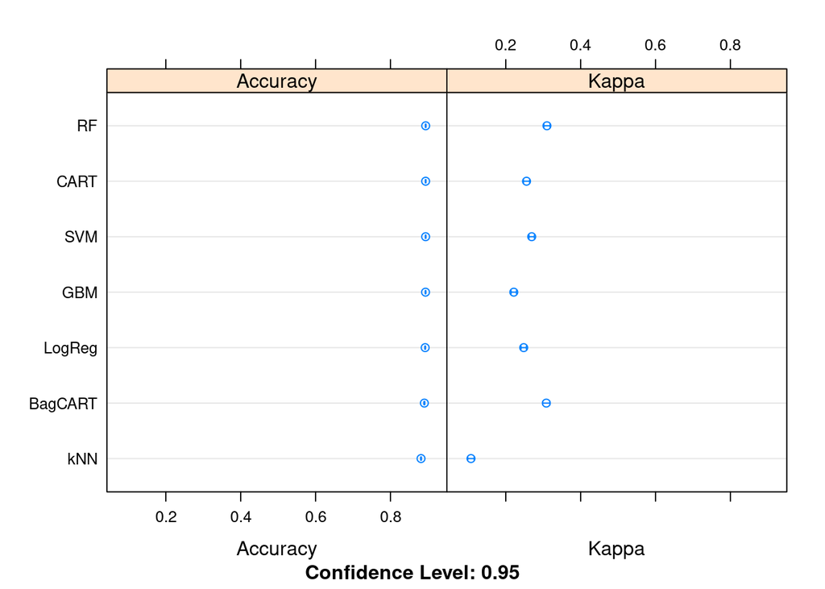

```r
dotplot(results)
```

## 5. Improve Accuracy or Results

After we achieve a short list of machine learning algorithms with good level of accuracy, we can leverage ways to improve the accuracy of the models:

- Search for a combination of parameters for each algorithm using caret that yields the best results.
- Combine the prediction of multiple models into an ensemble prediction using standalone algorithms or the caret Ensemble package.

### 5.a) Algorithm Tuning

Finally, we will tune the best-performing algorithms from each group further and see whether we can get more accuracy out of them.

```r
# Tuning algorithm #1 - Bagged CART
# Bagged CART requires no special tuning parameters.
startTimeModule <- proc.time()
set.seed(seedNum)
fit.final1 <- fit.bagcart
print(fit.final1)
```

```
## Bagged CART
##
## 36170 samples
##    15 predictor
##     2 classes: 'no', 'yes'
##
## No pre-processing
## Resampling: Cross-Validated (10 fold, repeated 3 times)
## Summary of sample sizes: 32553, 32554, 32553, 32553, 32553, 32552, ...
## Resampling results:
##
##   Accuracy   Kappa
##   0.8904985  0.3083093
```

```r
proc.time()-startTimeModule
```

```
##    user  system elapsed
##   0.025   0.000   0.025
```

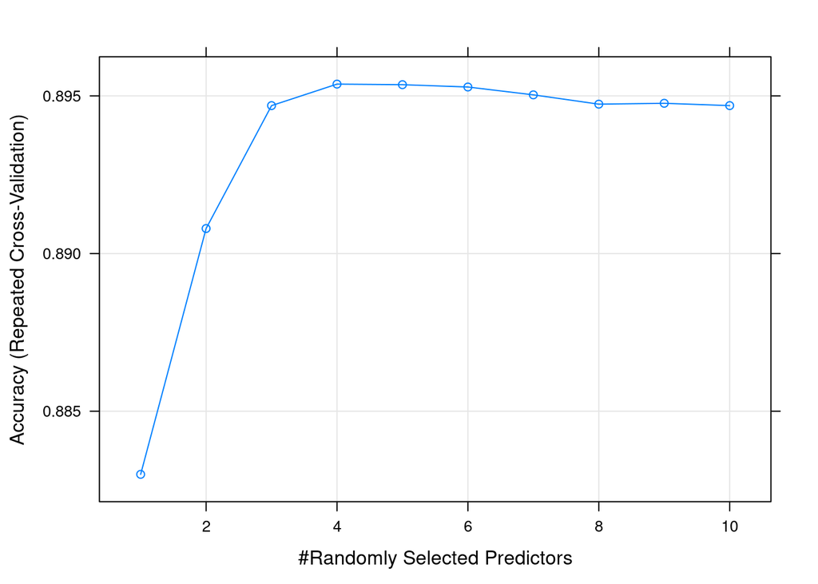

```r
# Tuning algorithm #2 - Random Forest
startTimeModule <- proc.time()
set.seed(seedNum)
grid <- expand.grid(mtry = c(1:10))
fit.final2 <- train(targetVar~., data=training, method="rf", metric=metricTarget, tuneGrid=grid, trControl=control)
plot(fit.final2)
```

```r
print(fit.final2)
```

```
## Random Forest
##
## 36170 samples
##    15 predictor
##     2 classes: 'no', 'yes'
##
## No pre-processing
## Resampling: Cross-Validated (10 fold, repeated 3 times)
## Summary of sample sizes: 32553, 32554, 32553, 32553, 32553, 32552, ...
## Resampling results across tuning parameters:
##
##   mtry  Accuracy   Kappa
##    1    0.8829970  0.0000000
##    2    0.8907935  0.1555908
##    3    0.8946917  0.2342187
##    4    0.8953737  0.2553644
##    5    0.8953552  0.2695852
##    6    0.8952815  0.2815247
##    7    0.8950327  0.2877775
##    8    0.8947378  0.2925837
##    9    0.8947654  0.2978303
##   10    0.8946917  0.2993777
##
## Accuracy was used to select the optimal model using the largest value.
## The final value used for the model was mtry = 4.
```

```r
proc.time()-startTimeModule
```

```
##      user    system   elapsed
## 25626.127   260.074 26193.240
```

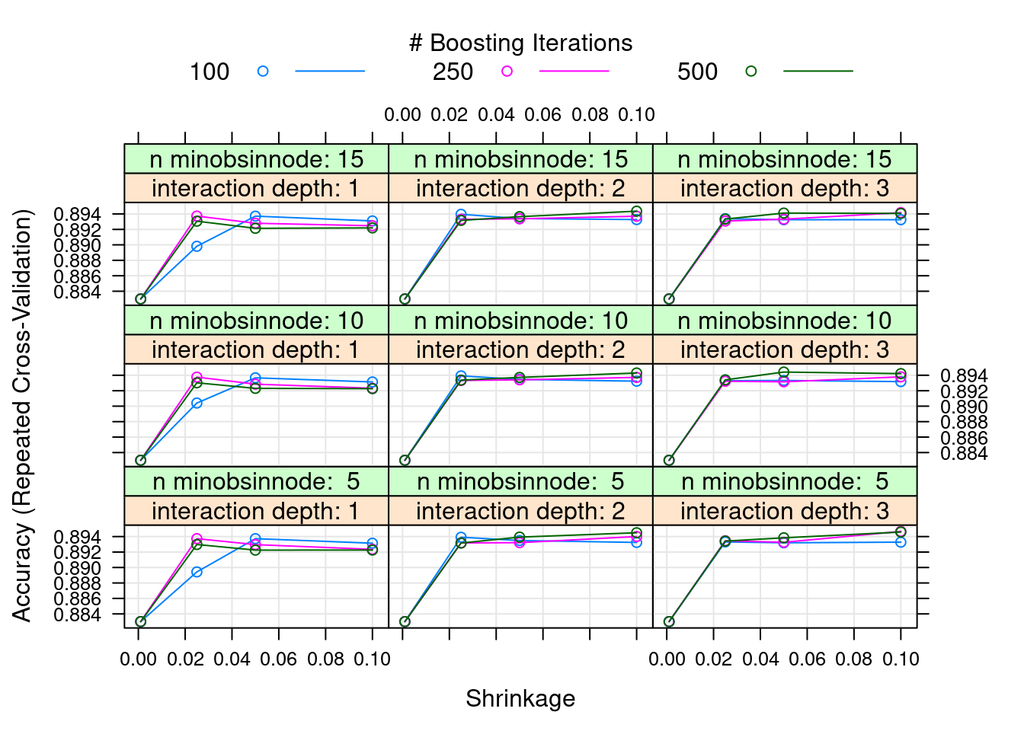

```r
# Tuning algorithm #3 - Stochastic Gradient Boosting
startTimeModule <- proc.time()
set.seed(seedNum)
grid <- expand.grid(.n.trees=c(100, 250, 500), .interaction.depth=c(1, 2, 3), .shrinkage=c(0.001, 0.025, 0.05, 0.1), .n.minobsinnode=c(5, 10, 15))
fit.final3 <- train(targetVar~., data=training, method="gbm", metric=metricTarget, tuneGrid=grid, trControl=control, verbose=F)
plot(fit.final3)
```

```r
print(fit.final3)
```

```
## Stochastic Gradient Boosting
##
## 36170 samples
##    15 predictor
##     2 classes: 'no', 'yes'
##
## No pre-processing
## Resampling: Cross-Validated (10 fold, repeated 3 times)
## Summary of sample sizes: 32553, 32554, 32553, 32553, 32553, 32552, ...
## Resampling results across tuning parameters:
##
##   shrinkage  interaction.depth  n.minobsinnode  n.trees  Accuracy
##   0.001      1                   5              100      0.8829970
##   0.001      1                   5              250      0.8829970
##   0.001      1                   5              500      0.8829970
##   0.001      1                  10              100      0.8829970
##   0.001      1                  10              250      0.8829970
##   0.001      1                  10              500      0.8829970
##   0.001      1                  15              100      0.8829970
##   0.001      1                  15              250      0.8829970
##   0.001      1                  15              500      0.8829970
##   0.001      2                   5              100      0.8829970
##   0.001      2                   5              250      0.8829970
##   0.001      2                   5              500      0.8829970
##   0.001      2                  10              100      0.8829970
##   0.001      2                  10              250      0.8829970
##   0.001      2                  10              500      0.8829970
##   0.001      2                  15              100      0.8829970
##   0.001      2                  15              250      0.8829970
##   0.001      2                  15              500      0.8829970
##   0.001      3                   5              100      0.8829970
##   0.001      3                   5              250      0.8829970
##   0.001      3                   5              500      0.8829970
##   0.001      3                  10              100      0.8829970
##   0.001      3                  10              250      0.8829970
##   0.001      3                  10              500      0.8829970
##   0.001      3                  15              100      0.8829970
##   0.001      3                  15              250      0.8829970
##   0.001      3                  15              500      0.8829970
##   0.025      1                   5              100      0.8894295
```

[output cut: 178 more lines]

```
##   0.2771054
##   0.2920330
##   0.2766445
##   0.2985719
##   0.3059842
##   0.2764571
##   0.2929771
##   0.3045148
##   0.2769248
##   0.2938786
##   0.3035965
##
## Accuracy was used to select the optimal model using the largest value.
## The final values used for the model were n.trees = 250,
##  interaction.depth = 3, shrinkage = 0.1 and n.minobsinnode = 5.
```

```r
proc.time()-startTimeModule
```

```
##      user    system   elapsed
## 19195.165    17.561 19443.937
```

### 5.d) Compare Algorithms After Tuning

```r
results <- resamples(list(BagCART=fit.final1, RF=fit.final2, GBM=fit.final3))
summary(results)
```

```
##
## Call:
## summary.resamples(object = results)
##
## Models: BagCART, RF, GBM
## Number of resamples: 30
##
## Accuracy
##              Min.   1st Qu.    Median      Mean   3rd Qu.      Max. NA's
## BagCART 0.8813606 0.8886816 0.8907784 0.8904985 0.8921142 0.8982582    0
## RF      0.8904867 0.8947259 0.8957700 0.8953737 0.8965994 0.8982582    0
## GBM     0.8896876 0.8927979 0.8949551 0.8946733 0.8968281 0.8999171    0
##
## Kappa
##              Min.   1st Qu.    Median      Mean   3rd Qu.      Max. NA's
## BagCART 0.2309389 0.2958858 0.3101073 0.3083093 0.3261475 0.3738435    0
## RF      0.2037094 0.2451940 0.2586975 0.2553644 0.2685058 0.2825267    0
## GBM     0.2640490 0.2836023 0.2994142 0.2985719 0.3130562 0.3402475    0
```

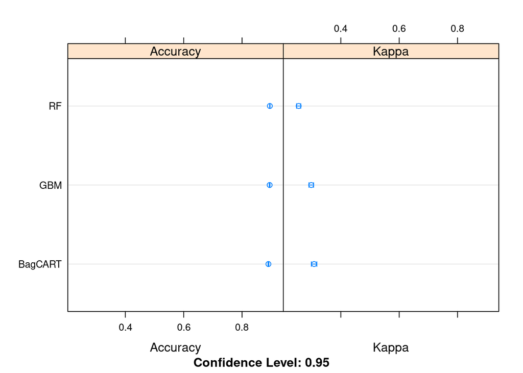

```r
dotplot(results)
```

## 6. Finalize Model and Present Results

Once we have narrow down to a model that we believe can make accurate predictions on unseen data, we are ready to finalize it. Finalizing a model may involve sub-tasks such as:

- Using an optimal model tuned to make predictions on unseen data.
- Creating a standalone model using the tuned parameters
- Saving an optimal model to file for later use.

### 6.a) Predictions on validation training

```r
predictClass <- predict(fit.final3, newdata=validation)
confusionMatrix(predictClass, validation$targetVar)
```

```
## Confusion Matrix and Statistics
##
##           Reference
## Prediction   no  yes
##        no  7842  836
##        yes  142  221
##
##                Accuracy : 0.8918
##                  95% CI : (0.8852, 0.8982)
##     No Information Rate : 0.8831
##     P-Value [Acc > NIR] : 0.004748
##
##                   Kappa : 0.2675
##  Mcnemar's Test P-Value : < 2.2e-16
##
##             Sensitivity : 0.9822
##             Specificity : 0.2091
##          Pos Pred Value : 0.9037
##          Neg Pred Value : 0.6088
##              Prevalence : 0.8831
##          Detection Rate : 0.8674
##    Detection Prevalence : 0.9598
##       Balanced Accuracy : 0.5956
##
##        'Positive' Class : no
##
```

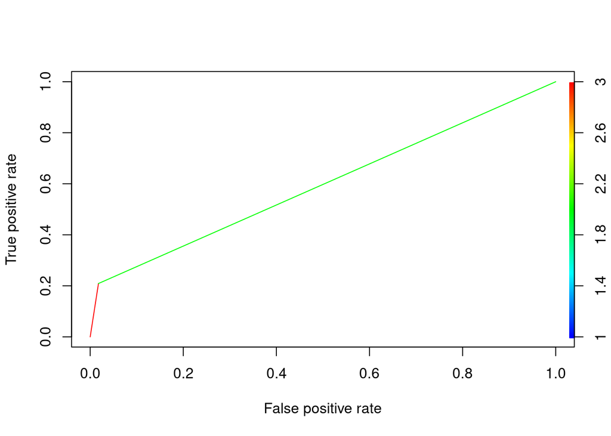

```r
pred <- prediction(as.numeric(predictClass), as.numeric(validation$targetVar))
perf <- performance(pred, measure = "tpr", x.measure = "fpr")
plot(perf, colorize=TRUE)
```

```r
auc <- performance(pred, measure = "auc")
auc <- auc@y.values[[1]]
auc
```

```
## [1] 0.5956484
```

### 6.b) Create standalone model on the entire dataset

```r
library(gbm)
startTimeModule <- proc.time()
set.seed(seedNum)
grid <- expand.grid(.n.trees=250, .interaction.depth=3, .shrinkage=0.1, .n.minobsinnode=5)
finalModel <- train(targetVar~., data=entireDataset, method="gbm", metric=metricTarget, tuneGrid=grid, trControl=control, verbose=F)
print(finalModel)
```

```
## Stochastic Gradient Boosting
##
## 45211 samples
##    15 predictor
##     2 classes: 'no', 'yes'
##
## No pre-processing
## Resampling: Cross-Validated (10 fold, repeated 3 times)
## Summary of sample sizes: 40690, 40690, 40690, 40690, 40690, 40689, ...
## Resampling results:
##
##   Accuracy   Kappa
##   0.8937796  0.2864032
##
## Tuning parameter 'n.trees' was held constant at a value of 250
##  3
## Tuning parameter 'shrinkage' was held constant at a value of 0.1
##
## Tuning parameter 'n.minobsinnode' was held constant at a value of 5
```

```r
proc.time()-startTimeModule
```

```
##    user  system elapsed
## 488.559   0.578 494.924
```

### 6.c) Save model for later use

```r
#saveRDS(finalModel, "./finalModel_BinaryClass.rds")
```

```r
proc.time()-startTimeScript
```

```
##      user    system   elapsed
## 82177.161   432.734 83612.335
```